# loans_Exploratory_Copy

```python
import pandas as pd
import numpy as np
import matplotlib.pyplot as plt
import seaborn as sb
import datetime as dt
from scipy import stats
from scipy.stats import norm
```

```python
df = pd.read_csv("prosperLoanData.csv")
df.head(10)
```

|  | ListingKey | ListingNumber | ListingCreationDate | CreditGrade | Term | LoanStatus | ClosedDate | BorrowerAPR | BorrowerRate | LenderYield | ... | LP_ServiceFees | LP_CollectionFees | LP_GrossPrincipalLoss | LP_NetPrincipalLoss | LP_NonPrincipalRecoverypayments | PercentFunded | Recommendations | InvestmentFromFriendsCount | InvestmentFromFriendsAmount | Investors |
| --- | --- | --- | --- | --- | --- | --- | --- | --- | --- | --- | --- | --- | --- | --- | --- | --- | --- | --- | --- | --- | --- |
| 0 | 1021339766868145413AB3B | 193129 | 2007-08-26 19:09:29.263000000 | C | 36 | Completed | 2009-08-14 00:00:00 | 0.16516 | 0.1580 | 0.1380 | ... | -133.18 | 0.0 | 0.0 | 0.0 | 0.0 | 1.0 | 0 | 0 | 0.0 | 258 |
| 1 | 10273602499503308B223C1 | 1209647 | 2014-02-27 08:28:07.900000000 | NaN | 36 | Current | NaN | 0.12016 | 0.0920 | 0.0820 | ... | 0.00 | 0.0 | 0.0 | 0.0 | 0.0 | 1.0 | 0 | 0 | 0.0 | 1 |
| 2 | 0EE9337825851032864889A | 81716 | 2007-01-05 15:00:47.090000000 | HR | 36 | Completed | 2009-12-17 00:00:00 | 0.28269 | 0.2750 | 0.2400 | ... | -24.20 | 0.0 | 0.0 | 0.0 | 0.0 | 1.0 | 0 | 0 | 0.0 | 41 |
| 3 | 0EF5356002482715299901A | 658116 | 2012-10-22 11:02:35.010000000 | NaN | 36 | Current | NaN | 0.12528 | 0.0974 | 0.0874 | ... | -108.01 | 0.0 | 0.0 | 0.0 | 0.0 | 1.0 | 0 | 0 | 0.0 | 158 |
| 4 | 0F023589499656230C5E3E2 | 909464 | 2013-09-14 18:38:39.097000000 | NaN | 36 | Current | NaN | 0.24614 | 0.2085 | 0.1985 | ... | -60.27 | 0.0 | 0.0 | 0.0 | 0.0 | 1.0 | 0 | 0 | 0.0 | 20 |
| 5 | 0F05359734824199381F61D | 1074836 | 2013-12-14 08:26:37.093000000 | NaN | 60 | Current | NaN | 0.15425 | 0.1314 | 0.1214 | ... | -25.33 | 0.0 | 0.0 | 0.0 | 0.0 | 1.0 | 0 | 0 | 0.0 | 1 |
| 6 | 0F0A3576754255009D63151 | 750899 | 2013-04-12 09:52:56.147000000 | NaN | 36 | Current | NaN | 0.31032 | 0.2712 | 0.2612 | ... | -22.95 | 0.0 | 0.0 | 0.0 | 0.0 | 1.0 | 0 | 0 | 0.0 | 1 |
| 7 | 0F1035772717087366F9EA7 | 768193 | 2013-05-05 06:49:27.493000000 | NaN | 36 | Current | NaN | 0.23939 | 0.2019 | 0.1919 | ... | -69.21 | 0.0 | 0.0 | 0.0 | 0.0 | 1.0 | 0 | 0 | 0.0 | 1 |
| 8 | 0F043596202561788EA13D5 | 1023355 | 2013-12-02 10:43:39.117000000 | NaN | 36 | Current | NaN | 0.07620 | 0.0629 | 0.0529 | ... | -16.77 | 0.0 | 0.0 | 0.0 | 0.0 | 1.0 | 0 | 0 | 0.0 | 1 |
| 9 | 0F043596202561788EA13D5 | 1023355 | 2013-12-02 10:43:39.117000000 | NaN | 36 | Current | NaN | 0.07620 | 0.0629 | 0.0529 | ... | -16.77 | 0.0 | 0.0 | 0.0 | 0.0 | 1.0 | 0 | 0 | 0.0 | 1 |

10 rows × 81 columns

```python
def showtable(df):
    '''
    Returns few key metrics of a dataframe.
    '''
    print(f"Dataset Shape: {df.shape}")
    summary = pd.DataFrame(df.dtypes,columns=['dtypes'])
    summary = summary.reset_index()
    summary['Name'] = summary['index']
    summary = summary[['Name','dtypes']]
    summary['Missing'] = df.isnull().sum().values
    summary['Uniques'] = df.nunique().values
    summary['First Value'] = df.loc[0].values
    summary['Second Value'] = df.loc[1].values
    summary['Third Value'] = df.loc[2].values

    for name in summary['Name'].value_counts().index:
        summary.loc[summary['Name'] == name, 'Entropy'] = round(stats.entropy(df[name].value_counts(normalize=True), base=2),2)

    return summary
```

```python
showtable(df)
```

```
Dataset Shape: (113937, 81)
```

|  | Name | dtypes | Missing | Uniques | First Value | Second Value | Third Value | Entropy |
| --- | --- | --- | --- | --- | --- | --- | --- | --- |
| 0 | ListingKey | object | 0 | 113066 | 1021339766868145413AB3B | 10273602499503308B223C1 | 0EE9337825851032864889A | 16.78 |
| 1 | ListingNumber | int64 | 0 | 113066 | 193129 | 1209647 | 81716 | 16.78 |
| 2 | ListingCreationDate | object | 0 | 113064 | 2007-08-26 19:09:29.263000000 | 2014-02-27 08:28:07.900000000 | 2007-01-05 15:00:47.090000000 | 16.78 |
| 3 | CreditGrade | object | 84984 | 8 | C | NaN | HR | 2.81 |
| 4 | Term | int64 | 0 | 3 | 36 | 36 | 36 | 0.85 |
| ... | ... | ... | ... | ... | ... | ... | ... | ... |
| 76 | PercentFunded | float64 | 0 | 719 | 1 | 1 | 1 | 0.14 |
| 77 | Recommendations | int64 | 0 | 17 | 0 | 0 | 0 | 0.26 |
| 78 | InvestmentFromFriendsCount | int64 | 0 | 14 | 0 | 0 | 0 | 0.15 |
| 79 | InvestmentFromFriendsAmount | float64 | 0 | 726 | 0 | 0 | 0 | 0.26 |
| 80 | Investors | int64 | 0 | 751 | 258 | 1 | 41 | 6.95 |

81 rows × 8 columns

```python
df.info()
```

```
<class 'pandas.core.frame.DataFrame'>
RangeIndex: 113937 entries, 0 to 113936
Data columns (total 81 columns):
ListingKey                             113937 non-null object
ListingNumber                          113937 non-null int64
ListingCreationDate                    113937 non-null object
CreditGrade                            28953 non-null object
Term                                   113937 non-null int64
LoanStatus                             113937 non-null object
ClosedDate                             55089 non-null object
BorrowerAPR                            113912 non-null float64
BorrowerRate                           113937 non-null float64
LenderYield                            113937 non-null float64
EstimatedEffectiveYield                84853 non-null float64
EstimatedLoss                          84853 non-null float64
EstimatedReturn                        84853 non-null float64
ProsperRating (numeric)                84853 non-null float64
ProsperRating (Alpha)                  84853 non-null object
ProsperScore                           84853 non-null float64
ListingCategory (numeric)              113937 non-null int64
BorrowerState                          108422 non-null object
Occupation                             110349 non-null object
EmploymentStatus                       111682 non-null object
EmploymentStatusDuration               106312 non-null float64
IsBorrowerHomeowner                    113937 non-null bool
CurrentlyInGroup                       113937 non-null bool
GroupKey                               13341 non-null object
DateCreditPulled                       113937 non-null object
CreditScoreRangeLower                  113346 non-null float64
CreditScoreRangeUpper                  113346 non-null float64
FirstRecordedCreditLine                113240 non-null object
CurrentCreditLines                     106333 non-null float64
OpenCreditLines                        106333 non-null float64
TotalCreditLinespast7years             113240 non-null float64
OpenRevolvingAccounts                  113937 non-null int64
OpenRevolvingMonthlyPayment            113937 non-null float64
InquiriesLast6Months                   113240 non-null float64
TotalInquiries                         112778 non-null float64
CurrentDelinquencies                   113240 non-null float64
AmountDelinquent                       106315 non-null float64
```

[output cut: 31 more lines]

```
LP_CustomerPayments                    113937 non-null float64
LP_CustomerPrincipalPayments           113937 non-null float64
LP_InterestandFees                     113937 non-null float64
LP_ServiceFees                         113937 non-null float64
LP_CollectionFees                      113937 non-null float64
LP_GrossPrincipalLoss                  113937 non-null float64
LP_NetPrincipalLoss                    113937 non-null float64
LP_NonPrincipalRecoverypayments        113937 non-null float64
PercentFunded                          113937 non-null float64
Recommendations                        113937 non-null int64
InvestmentFromFriendsCount             113937 non-null int64
InvestmentFromFriendsAmount            113937 non-null float64
Investors                              113937 non-null int64
dtypes: bool(3), float64(50), int64(11), object(17)
memory usage: 68.1+ MB
```

```python
def heatmap(data):
    corr = data.corr()
    fig,ax = plt.subplots(figsize=(15,15))
    sb.heatmap(corr,cmap="RdYlBu",annot=True,fmt=".2f",linewidths=.2)
    plt.xticks(range(len(corr.columns)),corr.columns)
    plt.yticks(range(len(corr.columns)),corr.columns)
    plt.show
#heatmap(df)
```

```python
## Features i'll select
'''
CreditGrade
Term
LoanStatus
ClosedDate
BorrowerAPR
BorrowerRate
LenderYield
EstimatedEffectiveYield
EstimatedLoss
EstimatedReturn
ProsperRating (numeric)
ProsperRating (Alpha)
ProsperScore
ListingCategory
BorrowerState
Occupation
EmploymentStatus
EmploymentStatusDuration
IsBorrowerHomeowner
IncomeRange
IncomeVerifiable
StatedMonthlyIncome
InquiriesLast6Months
TotalInquiries
BankcardUtilization
TotalTrades
OnTimeProsperPayments
LoanOriginalAmount
MonthlyLoanPayment
DebtToIncomeRatio
LoanOriginalAmount
'''
```

```
'\nCreditGrade  \nTerm\nLoanStatus\nClosedDate\nBorrowerAPR\nBorrowerRate\nLenderYield\nEstimatedEffectiveYield\nEstimatedLoss\nEstimatedReturn\nProsperRating (numeric)\nProsperRating (Alpha)\nProsperScore\nListingCategory\nBorrowerState\nOccupation\nEmploymentStatus\nEmploymentStatusDuration\nIsBor…
```

```python
colmuns = ["CreditGrade",  "Term","LoanStatus","ClosedDate","BorrowerAPR","BorrowerRate","LenderYield",
"EstimatedEffectiveYield","EstimatedLoss","EstimatedReturn","ProsperRating (numeric)","ProsperRating (Alpha)",
"ProsperScore","ListingCategory","BorrowerState","Occupation","EmploymentStatus","EmploymentStatusDuration",
"IsBorrowerHomeowner","IncomeRange","IncomeVerifiable","StatedMonthlyIncome","InquiriesLast6Months",
"TotalInquiries","BankcardUtilization","TotalTrades","OnTimeProsperPayments","LoanOriginalAmount",
"MonthlyLoanPayment","DebtToIncomeRatio","LoanOriginalAmount"]
```

```python
loans = pd.DataFrame(data = df,columns=colmuns)
```

```python
loans.head()
```

|  | CreditGrade | Term | LoanStatus | ClosedDate | BorrowerAPR | BorrowerRate | LenderYield | EstimatedEffectiveYield | EstimatedLoss | EstimatedReturn | ... | StatedMonthlyIncome | InquiriesLast6Months | TotalInquiries | BankcardUtilization | TotalTrades | OnTimeProsperPayments | LoanOriginalAmount | MonthlyLoanPayment | DebtToIncomeRatio | LoanOriginalAmount |
| --- | --- | --- | --- | --- | --- | --- | --- | --- | --- | --- | --- | --- | --- | --- | --- | --- | --- | --- | --- | --- | --- |
| 0 | C | 36 | Completed | 2009-08-14 00:00:00 | 0.16516 | 0.1580 | 0.1380 | NaN | NaN | NaN | ... | 3083.333333 | 3.0 | 3.0 | 0.00 | 11.0 | NaN | 9425 | 330.43 | 0.17 | 9425 |
| 1 | NaN | 36 | Current | NaN | 0.12016 | 0.0920 | 0.0820 | 0.07960 | 0.0249 | 0.05470 | ... | 6125.000000 | 3.0 | 5.0 | 0.21 | 29.0 | NaN | 10000 | 318.93 | 0.18 | 10000 |
| 2 | HR | 36 | Completed | 2009-12-17 00:00:00 | 0.28269 | 0.2750 | 0.2400 | NaN | NaN | NaN | ... | 2083.333333 | 0.0 | 1.0 | NaN | NaN | NaN | 3001 | 123.32 | 0.06 | 3001 |
| 3 | NaN | 36 | Current | NaN | 0.12528 | 0.0974 | 0.0874 | 0.08490 | 0.0249 | 0.06000 | ... | 2875.000000 | 0.0 | 1.0 | 0.04 | 26.0 | NaN | 10000 | 321.45 | 0.15 | 10000 |
| 4 | NaN | 36 | Current | NaN | 0.24614 | 0.2085 | 0.1985 | 0.18316 | 0.0925 | 0.09066 | ... | 9583.333333 | 1.0 | 9.0 | 0.81 | 39.0 | 11.0 | 15000 | 563.97 | 0.26 | 15000 |

5 rows × 31 columns

```python
print ("Rows           =",loans.shape[0])
print ("Columns        =",loans.shape[1])
print ("\nFeatures       =\n  ",loans.columns.to_list())
print ("\nNull Vlaues    =",loans.isnull().sum().values.sum())
print ("\nunique Vlaues  =\n",loans.nunique())
```

```
Rows           = 113937
Columns        = 31

Features       =
   ['CreditGrade', 'Term', 'LoanStatus', 'ClosedDate', 'BorrowerAPR', 'BorrowerRate', 'LenderYield', 'EstimatedEffectiveYield', 'EstimatedLoss', 'EstimatedReturn', 'ProsperRating (numeric)', 'ProsperRating (Alpha)', 'ProsperScore', 'ListingCategory', 'BorrowerState', 'Occupation', 'EmploymentStatus'…

Null Vlaues    = 568691

unique Vlaues  =
 CreditGrade                     8
Term                            3
LoanStatus                     12
ClosedDate                   2802
BorrowerAPR                  6677
BorrowerRate                 2294
LenderYield                  2283
EstimatedEffectiveYield      1582
EstimatedLoss                 120
EstimatedReturn              1476
ProsperRating (numeric)         7
ProsperRating (Alpha)           7
ProsperScore                   11
ListingCategory                 0
BorrowerState                  51
Occupation                     67
EmploymentStatus                8
EmploymentStatusDuration      605
IsBorrowerHomeowner             2
IncomeRange                     8
IncomeVerifiable                2
StatedMonthlyIncome         13502
InquiriesLast6Months           50
TotalInquiries                102
BankcardUtilization           201
TotalTrades                   108
OnTimeProsperPayments         127
LoanOriginalAmount           2468
MonthlyLoanPayment          23567
DebtToIncomeRatio            1207
LoanOriginalAmount           2468
dtype: int64
```

```python
loans.info()
```

```
<class 'pandas.core.frame.DataFrame'>
RangeIndex: 113937 entries, 0 to 113936
Data columns (total 31 columns):
CreditGrade                 28953 non-null object
Term                        113937 non-null int64
LoanStatus                  113937 non-null object
ClosedDate                  55089 non-null object
BorrowerAPR                 113912 non-null float64
BorrowerRate                113937 non-null float64
LenderYield                 113937 non-null float64
EstimatedEffectiveYield     84853 non-null float64
EstimatedLoss               84853 non-null float64
EstimatedReturn             84853 non-null float64
ProsperRating (numeric)     84853 non-null float64
ProsperRating (Alpha)       84853 non-null object
ProsperScore                84853 non-null float64
ListingCategory             0 non-null float64
BorrowerState               108422 non-null object
Occupation                  110349 non-null object
EmploymentStatus            111682 non-null object
EmploymentStatusDuration    106312 non-null float64
IsBorrowerHomeowner         113937 non-null bool
IncomeRange                 113937 non-null object
IncomeVerifiable            113937 non-null bool
StatedMonthlyIncome         113937 non-null float64
InquiriesLast6Months        113240 non-null float64
TotalInquiries              112778 non-null float64
BankcardUtilization         106333 non-null float64
TotalTrades                 106393 non-null float64
OnTimeProsperPayments       22085 non-null float64
LoanOriginalAmount          113937 non-null int64
MonthlyLoanPayment          113937 non-null float64
DebtToIncomeRatio           105383 non-null float64
LoanOriginalAmount          113937 non-null int64
dtypes: bool(2), float64(18), int64(3), object(8)
memory usage: 25.4+ MB
```

```python
loans = loans[loans["CreditGrade"].notnull()]
```

```python
loans.info()
```

```
<class 'pandas.core.frame.DataFrame'>
Int64Index: 28953 entries, 0 to 113927
Data columns (total 31 columns):
CreditGrade                 28953 non-null object
Term                        28953 non-null int64
LoanStatus                  28953 non-null object
ClosedDate                  28953 non-null object
BorrowerAPR                 28928 non-null float64
BorrowerRate                28953 non-null float64
LenderYield                 28953 non-null float64
EstimatedEffectiveYield     0 non-null float64
EstimatedLoss               0 non-null float64
EstimatedReturn             0 non-null float64
ProsperRating (numeric)     0 non-null float64
ProsperRating (Alpha)       0 non-null object
ProsperScore                0 non-null float64
ListingCategory             0 non-null float64
BorrowerState               23438 non-null object
Occupation                  26698 non-null object
EmploymentStatus            26698 non-null object
EmploymentStatusDuration    21347 non-null float64
IsBorrowerHomeowner         28953 non-null bool
IncomeRange                 28953 non-null object
IncomeVerifiable            28953 non-null bool
StatedMonthlyIncome         28953 non-null float64
InquiriesLast6Months        28256 non-null float64
TotalInquiries              27794 non-null float64
BankcardUtilization         21349 non-null float64
TotalTrades                 21409 non-null float64
OnTimeProsperPayments       2229 non-null float64
LoanOriginalAmount          28953 non-null int64
MonthlyLoanPayment          28953 non-null float64
DebtToIncomeRatio           27706 non-null float64
LoanOriginalAmount          28953 non-null int64
dtypes: bool(2), float64(18), int64(3), object(8)
memory usage: 6.7+ MB
```

```python
loans = loans[loans["EmploymentStatusDuration"].notnull()]
```

```python
loans.info()
```

```
<class 'pandas.core.frame.DataFrame'>
Int64Index: 21347 entries, 0 to 113927
Data columns (total 31 columns):
CreditGrade                 21347 non-null object
Term                        21347 non-null int64
LoanStatus                  21347 non-null object
ClosedDate                  21347 non-null object
BorrowerAPR                 21347 non-null float64
BorrowerRate                21347 non-null float64
LenderYield                 21347 non-null float64
EstimatedEffectiveYield     0 non-null float64
EstimatedLoss               0 non-null float64
EstimatedReturn             0 non-null float64
ProsperRating (numeric)     0 non-null float64
ProsperRating (Alpha)       0 non-null object
ProsperScore                0 non-null float64
ListingCategory             0 non-null float64
BorrowerState               19607 non-null object
Occupation                  21347 non-null object
EmploymentStatus            21347 non-null object
EmploymentStatusDuration    21347 non-null float64
IsBorrowerHomeowner         21347 non-null bool
IncomeRange                 21347 non-null object
IncomeVerifiable            21347 non-null bool
StatedMonthlyIncome         21347 non-null float64
InquiriesLast6Months        21327 non-null float64
TotalInquiries              21347 non-null float64
BankcardUtilization         21345 non-null float64
TotalTrades                 21345 non-null float64
OnTimeProsperPayments       2229 non-null float64
LoanOriginalAmount          21347 non-null int64
MonthlyLoanPayment          21347 non-null float64
DebtToIncomeRatio           20225 non-null float64
LoanOriginalAmount          21347 non-null int64
dtypes: bool(2), float64(18), int64(3), object(8)
memory usage: 4.9+ MB
```

```python
loans = loans[loans["BorrowerState"].notnull()]
```

```python
loans.info()
```

```
<class 'pandas.core.frame.DataFrame'>
Int64Index: 19607 entries, 0 to 113927
Data columns (total 31 columns):
CreditGrade                 19607 non-null object
Term                        19607 non-null int64
LoanStatus                  19607 non-null object
ClosedDate                  19607 non-null object
BorrowerAPR                 19607 non-null float64
BorrowerRate                19607 non-null float64
LenderYield                 19607 non-null float64
EstimatedEffectiveYield     0 non-null float64
EstimatedLoss               0 non-null float64
EstimatedReturn             0 non-null float64
ProsperRating (numeric)     0 non-null float64
ProsperRating (Alpha)       0 non-null object
ProsperScore                0 non-null float64
ListingCategory             0 non-null float64
BorrowerState               19607 non-null object
Occupation                  19607 non-null object
EmploymentStatus            19607 non-null object
EmploymentStatusDuration    19607 non-null float64
IsBorrowerHomeowner         19607 non-null bool
IncomeRange                 19607 non-null object
IncomeVerifiable            19607 non-null bool
StatedMonthlyIncome         19607 non-null float64
InquiriesLast6Months        19590 non-null float64
TotalInquiries              19607 non-null float64
BankcardUtilization         19606 non-null float64
TotalTrades                 19606 non-null float64
OnTimeProsperPayments       2193 non-null float64
LoanOriginalAmount          19607 non-null int64
MonthlyLoanPayment          19607 non-null float64
DebtToIncomeRatio           18508 non-null float64
LoanOriginalAmount          19607 non-null int64
dtypes: bool(2), float64(18), int64(3), object(8)
memory usage: 4.5+ MB
```

```python
loans = loans[loans["DebtToIncomeRatio"].notnull()]
```

```python
loans.info()
```

```
<class 'pandas.core.frame.DataFrame'>
Int64Index: 18508 entries, 0 to 113927
Data columns (total 31 columns):
CreditGrade                 18508 non-null object
Term                        18508 non-null int64
LoanStatus                  18508 non-null object
ClosedDate                  18508 non-null object
BorrowerAPR                 18508 non-null float64
BorrowerRate                18508 non-null float64
LenderYield                 18508 non-null float64
EstimatedEffectiveYield     0 non-null float64
EstimatedLoss               0 non-null float64
EstimatedReturn             0 non-null float64
ProsperRating (numeric)     0 non-null float64
ProsperRating (Alpha)       0 non-null object
ProsperScore                0 non-null float64
ListingCategory             0 non-null float64
BorrowerState               18508 non-null object
Occupation                  18508 non-null object
EmploymentStatus            18508 non-null object
EmploymentStatusDuration    18508 non-null float64
IsBorrowerHomeowner         18508 non-null bool
IncomeRange                 18508 non-null object
IncomeVerifiable            18508 non-null bool
StatedMonthlyIncome         18508 non-null float64
InquiriesLast6Months        18508 non-null float64
TotalInquiries              18508 non-null float64
BankcardUtilization         18507 non-null float64
TotalTrades                 18507 non-null float64
OnTimeProsperPayments       2099 non-null float64
LoanOriginalAmount          18508 non-null int64
MonthlyLoanPayment          18508 non-null float64
DebtToIncomeRatio           18508 non-null float64
LoanOriginalAmount          18508 non-null int64
dtypes: bool(2), float64(18), int64(3), object(8)
memory usage: 4.3+ MB
```

```python
loans.drop(["OnTimeProsperPayments","EstimatedEffectiveYield","EstimatedLoss","EstimatedReturn","ProsperRating (numeric)",
             "ProsperRating (Alpha)","ProsperScore","ListingCategory"],axis=1,inplace=True)
```

```python
loans.info()
```

```
<class 'pandas.core.frame.DataFrame'>
Int64Index: 18508 entries, 0 to 113927
Data columns (total 23 columns):
CreditGrade                 18508 non-null object
Term                        18508 non-null int64
LoanStatus                  18508 non-null object
ClosedDate                  18508 non-null object
BorrowerAPR                 18508 non-null float64
BorrowerRate                18508 non-null float64
LenderYield                 18508 non-null float64
BorrowerState               18508 non-null object
Occupation                  18508 non-null object
EmploymentStatus            18508 non-null object
EmploymentStatusDuration    18508 non-null float64
IsBorrowerHomeowner         18508 non-null bool
IncomeRange                 18508 non-null object
IncomeVerifiable            18508 non-null bool
StatedMonthlyIncome         18508 non-null float64
InquiriesLast6Months        18508 non-null float64
TotalInquiries              18508 non-null float64
BankcardUtilization         18507 non-null float64
TotalTrades                 18507 non-null float64
LoanOriginalAmount          18508 non-null int64
MonthlyLoanPayment          18508 non-null float64
DebtToIncomeRatio           18508 non-null float64
LoanOriginalAmount          18508 non-null int64
dtypes: bool(2), float64(11), int64(3), object(7)
memory usage: 3.1+ MB
```

```python
loans = loans[loans["TotalTrades"].notnull()]
loans.info()
```

```
<class 'pandas.core.frame.DataFrame'>
Int64Index: 18507 entries, 0 to 113927
Data columns (total 23 columns):
CreditGrade                 18507 non-null object
Term                        18507 non-null int64
LoanStatus                  18507 non-null object
ClosedDate                  18507 non-null object
BorrowerAPR                 18507 non-null float64
BorrowerRate                18507 non-null float64
LenderYield                 18507 non-null float64
BorrowerState               18507 non-null object
Occupation                  18507 non-null object
EmploymentStatus            18507 non-null object
EmploymentStatusDuration    18507 non-null float64
IsBorrowerHomeowner         18507 non-null bool
IncomeRange                 18507 non-null object
IncomeVerifiable            18507 non-null bool
StatedMonthlyIncome         18507 non-null float64
InquiriesLast6Months        18507 non-null float64
TotalInquiries              18507 non-null float64
BankcardUtilization         18507 non-null float64
TotalTrades                 18507 non-null float64
LoanOriginalAmount          18507 non-null int64
MonthlyLoanPayment          18507 non-null float64
DebtToIncomeRatio           18507 non-null float64
LoanOriginalAmount          18507 non-null int64
dtypes: bool(2), float64(11), int64(3), object(7)
memory usage: 3.1+ MB
```

- CreditGrade :: The Credit rating that was assigned at the time the listing went live. Applicable for listings pre-2009 period and will only be populated for those listings.
- Term ::: The length of the loan expressed in months.
- LoanStatus ::: The current status of the loan: Cancelled, Chargedoff, Completed, Current, Defaulted, FinalPaymentInProgress, PastDue. The PastDue status will be accompanied by a delinquency bucket.
- ClosedDate ::: Closed date is applicable for Cancelled, Completed, Chargedoff and Defaulted loan statuses.
- BorrowerAPR ::: The Borrower's Annual Percentage Rate (APR) for the loan.
- BorrowerRate ::: The Borrower's interest rate for this loan.
- LenderYield ::: The Lender yield on the loan. Lender yield is equal to the interest rate on the loan less the servicing fee.
- BorrowerState :::The two letter abbreviation of the state of the address of the borrower at the time the Listing was created.
- Occupation ::: The Occupation selected by the Borrower at the time they created the listing.
- EmploymentStatus ::: The employment status of the borrower at the time they posted the listing.
- EmploymentStatusDuration ::: The length in months of the employment status at the time the listing was created.
- IsBorrowerHomeowner ::: A Borrower will be classified as a homowner if they have a mortgage on their credit profile or provide documentation confirming they are a homeowner.
- IncomeRange ::: The income range of the borrower at the time the listing was created.
- IncomeVerifiable ::: The borrower indicated they have the required documentation to support their income.
- StatedMonthlyIncome ::: The monthly income the borrower stated at the time the listing was created.
- InquiriesLast6Months ::: Number of inquiries in the past six months at the time the credit profile was pulled.
- TotalInquiries ::: Total number of inquiries at the time the credit profile was pulled.
- BankcardUtilization ::: The percentage of available revolving credit that is utilized at the time the credit profile was pulled.
- TotalTrades ::: Number of trade lines ever opened at the time the credit profile was pulled.
- LoanOriginalAmount ::: The origination amount of the loan.
- MonthlyLoanPayment :::: The scheduled monthly loan payment.
- DebtToIncomeRatio ::: The debt to income ratio of the borrower at the time the credit profile was pulled. This value is Null if the debt to income ratio is not available. This value is capped at 10.01 (any debt to income ratio larger than 1000% will be returned as 1001%).
- LoanOriginalAmount ::: The origination amount of the loan.

### Now There is no nulls

```python
loans.to_csv("loans.csv")
```

```python
loans.head()
```

|  | CreditGrade | Term | LoanStatus | ClosedDate | BorrowerAPR | BorrowerRate | LenderYield | BorrowerState | Occupation | EmploymentStatus | ... | IncomeVerifiable | StatedMonthlyIncome | InquiriesLast6Months | TotalInquiries | BankcardUtilization | TotalTrades | LoanOriginalAmount | MonthlyLoanPayment | DebtToIncomeRatio | LoanOriginalAmount |
| --- | --- | --- | --- | --- | --- | --- | --- | --- | --- | --- | --- | --- | --- | --- | --- | --- | --- | --- | --- | --- | --- |
| 0 | C | 36 | Completed | 2009-08-14 00:00:00 | 0.16516 | 0.1580 | 0.1380 | CO | Other | Self-employed | ... | True | 3083.333333 | 3.0 | 3.0 | 0.00 | 11.0 | 9425 | 330.43 | 0.17 | 9425 |
| 21 | D | 36 | Completed | 2010-12-12 00:00:00 | 0.21488 | 0.2075 | 0.1975 | MI | Professional | Full-time | ... | True | 3750.000000 | 0.0 | 8.0 | 0.08 | 6.0 | 3000 | 112.64 | 0.09 | 3000 |
| 46 | C | 36 | Completed | 2010-01-29 00:00:00 | 0.17170 | 0.1500 | 0.1400 | IL | Accountant/CPA | Full-time | ... | True | 3166.666667 | 1.0 | 7.0 | 0.68 | 27.0 | 4000 | 138.66 | 0.27 | 4000 |
| 59 | C | 36 | Completed | 2010-09-26 00:00:00 | 0.16717 | 0.1600 | 0.1500 | IL | Other | Full-time | ... | True | 2750.000000 | 2.0 | 2.0 | 0.41 | 23.0 | 7000 | 244.47 | 0.37 | 7000 |
| 62 | D | 36 | Chargedoff | 2009-11-24 00:00:00 | 0.23748 | 0.2300 | 0.2100 | CA | Other | Full-time | ... | True | 3891.666667 | 3.0 | 6.0 | 0.89 | 23.0 | 23500 | 909.68 | 0.59 | 23500 |

5 rows × 23 columns

### BorrowerState :: The two letter abbreviation of the state of the address of the borrower at the time the Listing was created.

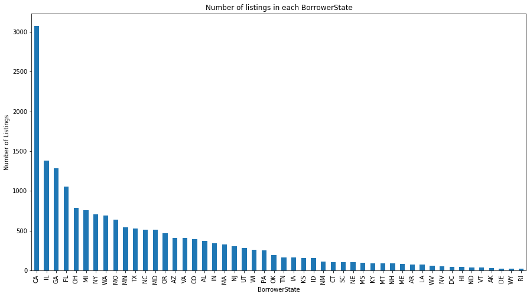

```python
state_counts = loans["BorrowerState"].value_counts()
base_color = sb.color_palette()[0]

plt.figure(figsize=(15, 8))
state_counts.plot(kind='bar', color=base_color);

plt.title('Number of listings in each BorrowerState');
plt.xlabel('BorrowerState');
plt.ylabel('Number of Listings');

plt.xticks(rotation=90);
```

CA is highest listing counts, and followed by IL,GA,FL,OH and MI

```python
loans["LoanStatus"].unique()
```

```
array(['Completed', 'Chargedoff', 'Defaulted', 'Cancelled'], dtype=object)
```

### LoanStatus ::: The current status of the loan: Cancelled, Chargedoff, Completed, Current, Defaulted, FinalPaymentInProgress, PastDue. The PastDue status will be accompanied by a delinquency bucket.

```python
Loan_Status_counts = loans["LoanStatus"].value_counts()
```

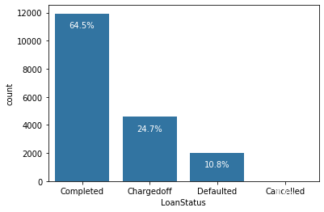

```python
# create the plot
base_color = sb.color_palette()[0]
sb.countplot(data = loans, x = 'LoanStatus', color = base_color)

# add annotations
n_points = loans.shape[0]
locs, labels = plt.xticks() # get the current tick locations and labels

# loop through each pair of locations and labels
for loc, label in zip(locs, labels):

    # get the text property for the label to get the correct count
    count = Loan_Status_counts[label.get_text()]
    pct_string = '{:.1f}%'.format(100*count/n_points)

    # print the annotation just below the top of the bar
    plt.text(loc, count-1000, pct_string, ha = 'center', color = 'w')
```

the plot above shows us the most listings completed its loan,there are 64. is complete its loan , 24.7 charged off and 10.8% Defaulted

### IsBorrowerHomeowner :: A Borrower will be classified as a homowner if they have a mortgage on their credit profile or provide documentation confirming they are a homeowner.

```python
loans["IsBorrowerHomeowner"].unique()
```

```
array([ True, False])
```

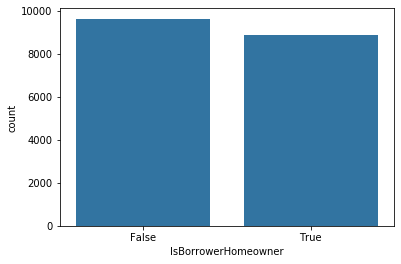

```python
# create the plot
base_color = sb.color_palette()[0]
homeowner_counts = loans["IsBorrowerHomeowner"].value_counts()
sb.countplot(data = loans, x = 'IsBorrowerHomeowner', color = base_color)
```

if the customer is a home owner or not but this feature it's almost equal it's not useful .

### IncomeRange ::: The income range of the borrower at the time the listing was created.

```python
loans["IncomeRange"].unique()
```

```
array(['$25,000-49,999', '$50,000-74,999', 'Not employed',
       '$75,000-99,999', '$100,000+', '$1-24,999', 'Not displayed'],
      dtype=object)
```

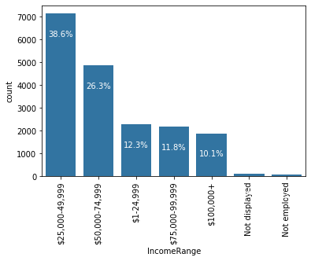

```python
# create the plot
base_color = sb.color_palette()[0]
income_order = loans['IncomeRange'].value_counts().index
sb.countplot(data = loans, x = 'IncomeRange', color = base_color,order=income_order)

# add annotations
income_range_counts = loans["IncomeRange"].value_counts()

n_points = loans.shape[0]
locs, labels = plt.xticks(rotation = 90) # get the current tick locations and labels

# loop through each pair of locations and labels
for loc, label in zip(locs, labels):

    # get the text property for the label to get the correct count
    count = income_range_counts[label.get_text()]
    pct_string = '{:.1f}%'.format(100*count/n_points)

    # print the annotation just below the top of the bar
    plt.text(loc, count-1000, pct_string, ha = 'center', color = 'w')
```

The income rate distribution is analyzed to know the average income rate of listings. the plot shows that the loans fall when the income less than 50000 $

```python
loans.BorrowerRate.describe()
```

```
count    18507.000000
mean         0.180751
std          0.076814
min          0.000000
25%          0.123400
50%          0.162700
75%          0.230000
max          0.360000
Name: BorrowerRate, dtype: float64
```

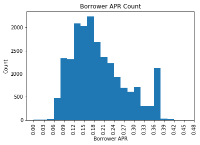

```python
ticks =list(np.arange(0, 0.5, 0.03))
labels = ['{:.2f}'.format(v) for v in ticks]
bins = np.arange(0, loans['BorrowerAPR'].max()+.02, .02)
plt.hist(data = loans, x = 'BorrowerAPR', bins = bins);
plt.xticks(ticks, labels);
plt.xticks(rotation = 90);
plt.xlabel('Borrower APR')
plt.ylabel('Count')
plt.title("Borrower APR Count");
```

```python
loans['BorrowerAPR'].describe()
```

```
count    18507.000000
mean         0.194840
std          0.080408
min          0.006530
25%          0.134110
50%          0.176770
75%          0.242640
max          0.413550
Name: BorrowerAPR, dtype: float64
```

```python
loans['CreditGrade'].unique()
```

```
array(['C', 'D', 'E', 'A', 'B', 'AA', 'HR'], dtype=object)
```

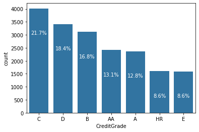

```python
# create the plot
base_color = sb.color_palette()[0]
credit_grade_order = loans['CreditGrade'].value_counts().index
sb.countplot(data = loans, x = 'CreditGrade', color = base_color,order=credit_grade_order)

# add annotations
credit_grade_counts = loans["CreditGrade"].value_counts()

n_points = loans.shape[0]
locs, labels = plt.xticks() # get the current tick locations and labels

# loop through each pair of locations and labels
for loc, label in zip(locs, labels):

    # get the text property for the label to get the correct count
    count = credit_grade_counts[label.get_text()]
    pct_string = '{:.1f}%'.format(100*count/n_points)

    # print the annotation just below the top of the bar
    plt.text(loc, count-1000, pct_string, ha = 'center', color = 'w')
```

```python
loans['BorrowerRate'].unique()
```

```
array([0.158 , 0.2075, 0.15  , ..., 0.2309, 0.1151, 0.0689])
```

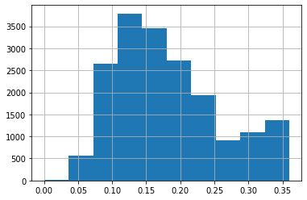

```python
loans['BorrowerRate'].hist()
```

```python
loans['BorrowerRate'].describe()
```

```
count    18507.000000
mean         0.180751
std          0.076814
min          0.000000
25%          0.123400
50%          0.162700
75%          0.230000
max          0.360000
Name: BorrowerRate, dtype: float64
```

## Analyse how the BorrowerRate changed with income range for Homeowners vs Non-Homeowners

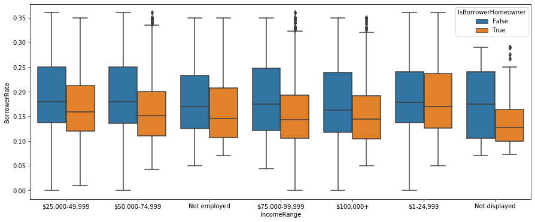

```python
p = sb.boxplot(data=loans, x='IncomeRange', y='BorrowerRate', hue='IsBorrowerHomeowner');
p.figure.set_figwidth(15)
p.figure.set_figheight(6)
```

## Employment Status

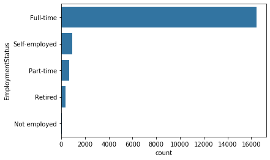

```python
# create the plot
base_color = sb.color_palette()[0]
employ_order = loans['EmploymentStatus'].value_counts().index
sb.countplot(data = loans, y = 'EmploymentStatus', color = base_color,order=employ_order)

# add annotations
employ_count = loans['EmploymentStatus'].value_counts()
max_employ_count = loans['EmploymentStatus'].value_counts()[0]
```

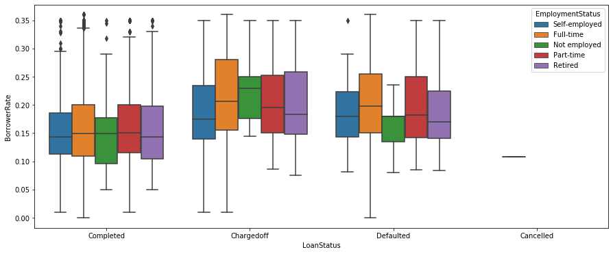

```python
p = sb.boxplot(data=loans, x='LoanStatus', y='BorrowerRate', hue='EmploymentStatus');
p.figure.set_figwidth(15)
p.figure.set_figheight(6)
```

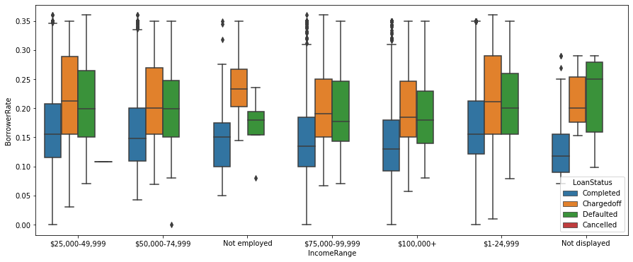

```python
p = sb.boxplot(data=loans, x='IncomeRange', y='BorrowerRate',hue="LoanStatus");
p.figure.set_figwidth(15)
p.figure.set_figheight(6)
```

I see when the interest rate for the loan is high,the chance for chargedOff or Defaulted is increased event with the people with high income range.

### Total Inquiries

```python
tot_inquiries_order = loans['TotalInquiries'].value_counts().head(20).index
```

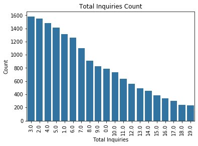

```python
# create the plot
base_color = sb.color_palette()[0]
sb.countplot(data = loans, x = 'TotalInquiries', color = base_color,order=tot_inquiries_order)
plt.xticks(rotation = 90);
plt.xlabel('Total Inquiries')
plt.ylabel('Count')
plt.title('Total Inquiries Count');
```

### Monthly payment histogram

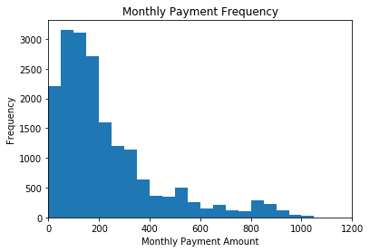

```python
bins = np.arange(0, 1300, 50)
loans['MonthlyLoanPayment'].plot(kind = 'hist', bins = bins)
plt.xlim((0,1200))
plt.xlabel('Monthly Payment Amount')
plt.title('Monthly Payment Frequency');
```

```python
loans['MonthlyLoanPayment'].describe()
```

```
count    18507.000000
mean       227.268562
std        203.117604
min          0.000000
25%         90.380000
50%        163.300000
75%        294.920000
max       1130.900000
Name: MonthlyLoanPayment, dtype: float64
```

the mean of Monthly loan payment is 227 dollar ,the most of Borrower have monthly payment less than 400 dollar.

### Debt To Income Ratio

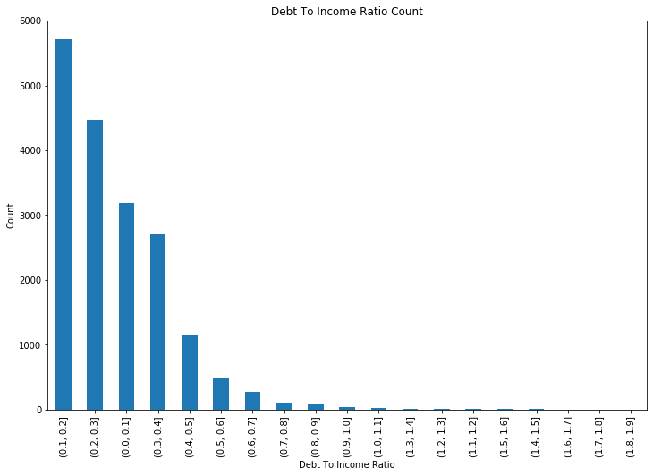

```python
ratio_bin = np.arange(0,2,0.1)
bins = pd.cut(loans['DebtToIncomeRatio'], ratio_bin)
debt_ratio = pd.value_counts(bins)
plt.figure(figsize= (12,8))
debt_ratio.plot(kind = 'bar', color = base_color);
plt.xlabel('Debt To Income Ratio')
plt.ylabel('Count')
plt.title('Debt To Income Ratio Count');
```

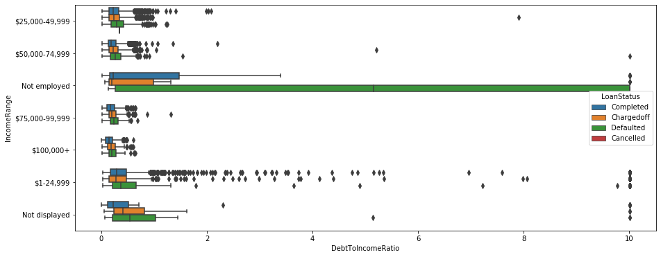

```python
p = sb.boxplot(data=loans, x='DebtToIncomeRatio', y='IncomeRange',hue="LoanStatus");
p.figure.set_figwidth(15)
p.figure.set_figheight(6)
```

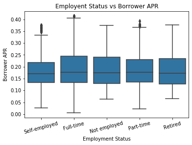

```python
sb.boxplot(data = loans, y = 'BorrowerAPR', x = 'EmploymentStatus', color = base_color);
plt.xlabel('Employment Status')
plt.ylabel('Borrower APR')
plt.title('Employent Status vs Borrower APR');
plt.xticks(rotation = 15);
```

Borrower APR was highest in Full-Time and not employed group.

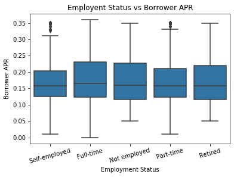

```python
sb.boxplot(data = loans, y = 'BorrowerRate', x = 'EmploymentStatus', color = base_color);
plt.xlabel('Employment Status')
plt.ylabel('Borrower APR')
plt.title('Employent Status vs Borrower APR');
plt.xticks(rotation = 15);
```

Borrower Rate was highest in Full-Time and not employed group.

## Summary :

Regarding the relationship between loan status and borrower APR, with a high APR increase the chance for Defaluted or Charged off.